# Regression - Exercises 4

Arndt Allhorn

May 24, 2018

# Exercise 2

```r
data(CPS1985)
males <- CPS1985[CPS1985$gender=="male",]
females <- CPS1985[CPS1985$gender=="female",]
```

Estimate for both subsamples a multiple regression model for log(wage) on years of education, years of professional experience and squared experience. Consider the output from the respective summary for each of the subsamples:

```r
lmm = lm(log(wage)~ education + experience + I(experience^2), data=males)
summary(lmm)
```

```
Call:
lm(formula = log(wage) ~ education + experience + I(experience^2),
    data = males)

Residuals:
     Min       1Q   Median       3Q      Max
-2.30555 -0.28375  0.00593  0.33371  1.27644

Coefficients:
                  Estimate Std. Error t value Pr(>|t|)
(Intercept)      0.6619812  0.1577047   4.198 3.61e-05 ***
education        0.0794123  0.0107741   7.371 1.85e-12 ***
experience       0.0448511  0.0074210   6.044 4.70e-09 ***
I(experience^2) -0.0006698  0.0001652  -4.055 6.47e-05 ***
---
Signif. codes:  0 ‘***’ 0.001 ‘**’ 0.01 ‘*’ 0.05 ‘.’ 0.1 ‘ ’ 1

Residual standard error: 0.4577 on 285 degrees of freedom
Multiple R-squared:  0.2742,    Adjusted R-squared:  0.2666
F-statistic: 35.89 on 3 and 285 DF,  p-value: < 2.2e-16
```

```r
lmf = lm(log(wage)~ education + experience + I(experience^2), data=females)
summary(lmf)
```

```
Call:
lm(formula = log(wage) ~ education + experience + I(experience^2),
    data = females)

Residuals:
     Min       1Q   Median       3Q      Max
-1.09291 -0.29917 -0.01742  0.28206  2.01924

Coefficients:
                  Estimate Std. Error t value Pr(>|t|)
(Intercept)      0.2225431  0.1798517   1.237  0.21715
education        0.1091510  0.0118606   9.203  < 2e-16 ***
experience       0.0259759  0.0078578   3.306  0.00109 **
I(experience^2) -0.0003885  0.0001711  -2.271  0.02405 *
---
Signif. codes:  0 ‘***’ 0.001 ‘**’ 0.01 ‘*’ 0.05 ‘.’ 0.1 ‘ ’ 1

Residual standard error: 0.4193 on 241 degrees of freedom
Multiple R-squared:  0.283, Adjusted R-squared:  0.2741
F-statistic: 31.72 on 3 and 241 DF,  p-value: < 2.2e-16
```

#### (a) How could you determine the sample sizes of the two subsamples?

degrees of freedom + number of coefficients = sample size

#### (b) Which of the coefficients are sigficantly different from 0, if we assume a level of significance of 5%?

(Does this change if we would use 1%?)

#### (c) How could you calculate the values of RSS for both models? Would it be useful to compare them?

To calculate RSS you have to sum up all the squared residuals:
$$RSS = \sum(\hat y-y)^2$$

```r
sum(lmm$residuals^2)
```

```
[1] 59.70644
```

```r
deviance(lmm)
```

```
[1] 59.70644
```

```r
sum(lmf$residuals^2)
```

```
[1] 42.36601
```

```r
deviance(lmf)
```

```
[1] 42.36601
```

#### (d) Predict log(wage) for both models for a person with 12 years of education and 10 year of professional experience. What do you observe?

```r
predict(lmm, data.frame(education=12, experience=10))
```

```
       1
1.996459
```

```r
predict(lmf, data.frame(education=12, experience=10))
```

```
       1
1.753265
```

There is a difference between females and males!

#### (e) Generate graphs for the marginal effects of experience for both models, i.e. display the estimated quadratic functions while setting education equal to 12 for example. (Note that 12 is the median of education in the full sample.)

```r
xrange <- range(males$experience, females$experience)
beta <- lmm$coefficients
curve(beta[1] + beta[2]*12 + beta[3]*x + beta[4]*x^2, lwd=2, xlim=xrange, col="red")
beta <- lmf$coefficients
curve(beta[1] + beta[2]*12 + beta[3]*x + beta[4]*x^2, lwd=2, add=T, col="blue")
```

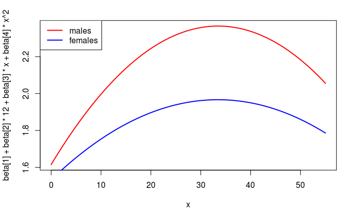

```r
legend("topleft",c("males","females"),lwd=2,col=c("red","blue"))
```